# **NEXT STEPS**

- instead of spatial lag (average kg received within xxkm radius), calculate total kg received within xxkm radius - check that those values have stronger correlations
- try the same for kg processed
- try the same for kg created

# Spatial lag of explanatory variables

Spatial lag assumes that conditions of your neighborhood has an affect on you. For example, if you are studying the correlation between, let's say, obesity rates and the amount of fast food chains, you would intuitively understand that someone's obesity rate is not only affected by the number of fast food chains on their block, but also the number of fast food chains in their neighborhood, city, region, or even country. So knowing this, the explanatory variables to test when finding out what affects obesity rates wouldn't just be number of fast food chains in that postcode - it would be number of fast food chains with 3, 10, 30km of that post code as well.

```python
import os
import pandas as pd
import geopandas as gpd
import numpy as np
import matplotlib.pyplot as plt
import feather
import plotly.express as px
import psutil
import libpysal as lp
import rasterio as rio
import contextily as ctx
import shapely.geometry as geom
import mapclassify as mc
import seaborn as sn
%matplotlib inline
```

## Import LMA dataset

Here, we read the LMA dataset as a dataframe. Each row represents a 4-digit postcode, log(kg received), and log(kg processed) with that postcode.

```python
# read dataframe
df = feather.read_dataframe('../data/lma/af_2019-2020_matched-codes.feather')
df = df[~df.gnc.isna()] # extract rows with gnc
df = df[df.year == 2019] # only looking at numbers in 2019
df.eaPostcode = df.eaPostcode.str[:4].astype('int64') # convert to pc4
df.herPostcode = df.herPostcode.str[:4].astype('int64')
df = df[['eaPostcode','herPostcode', 'kg']]

# make df for received per pc
dfEa = df.groupby(['eaPostcode']).sum().kg.reset_index()
dfEa.rename(columns={'eaPostcode': 'postcode', 'kg': 'kg_received'}, inplace=True)

# make df for processed per pc
dfHer = df.groupby(['herPostcode']).sum().kg.reset_index()
dfHer.rename(columns={'herPostcode': 'postcode', 'kg': 'kg_processed'}, inplace=True)

# merge with nlpc4
nl_pc4 = gpd.read_file('../data/spatial-data/nl_pc4.shp')
nl_pc4 = nl_pc4[['PC4', 'geometry']]
nl_pc4.PC4 = nl_pc4.PC4.astype('int64')
nl_pc4 = nl_pc4.to_crs('EPSG:28992') # reprojecting to amersfoort CRS (where units is not degrees but meters, see https://epsg.io/28992)
df = pd.merge(nl_pc4, dfEa, how='left', left_on='PC4', right_on='postcode')
df = pd.merge(df, dfHer, how='left', left_on='PC4', right_on='postcode')
df = df.drop(labels=['postcode_x', 'postcode_y'], axis=1)
df = df.rename(columns={'PC4': 'pc'})

# column with log_kg
def log(x):
    if x > 0:
        return np.log(x)
    else:
        return 0
df['log_kg_received'] = df.kg_received.map(lambda x: log(x))
df['log_kg_processed'] = df.kg_processed.map(lambda x: log(x))

# add centroids
df = gpd.GeoDataFrame(df)
df['centroid'] = df.geometry.centroid
df = df.fillna(0)

# display
print('rows, columns: {}'.format(df.shape))
df = df[['pc', 'geometry', 'centroid', 'kg_received', 'kg_processed', 'log_kg_received', 'log_kg_processed']]
df.head()
```

```
rows, columns: (4068, 7)
```

|  | pc | geometry | centroid | kg_received | kg_processed | log_kg_received | log_kg_processed |
| --- | --- | --- | --- | --- | --- | --- | --- |
| 0 | 1011 | POLYGON ((122183.249 487939.201, 122183.241 48... | POINT (122198.228 487226.936) | 0.0 | 0.0 | 0.000000 | 0.0 |
| 1 | 1012 | POLYGON ((122049.209 488210.972, 122120.438 48... | POINT (121551.910 487520.955) | 0.0 | 0.0 | 0.000000 | 0.0 |
| 2 | 1013 | POLYGON ((120047.752 491287.512, 120402.310 49... | POINT (120106.469 490017.332) | 0.0 | 0.0 | 0.000000 | 0.0 |
| 3 | 1014 | MULTIPOLYGON (((120388.477 489860.258, 120387.... | POINT (119173.140 489416.889) | 4160400.0 | 0.0 | 15.241122 | 0.0 |
| 4 | 1015 | POLYGON ((120603.279 488589.178, 120640.375 48... | POINT (120734.238 487948.768) | 0.0 | 0.0 | 0.000000 | 0.0 |

## Spatial weights

- https://pysal.org/notebooks/lib/libpysal/weights.html
- https://splot.readthedocs.io/en/stable/users/tutorials/weights.html#pysal-spatial-weight-types
- https://pysal.org/libpysal/generated/libpysal.weights.DistanceBand.html
- http://darribas.org/gds_scipy16/ipynb_md/03_spatial_weights.html

```python
# make spatial weight matrixes for 4, 10, 30, 50km
wd4 = lp.weights.DistanceBand.from_dataframe(df, threshold=4000, silence_warnings=True)
wd4.transform = 'r'
wd10 = lp.weights.DistanceBand.from_dataframe(df, threshold=10000, silence_warnings=True)
wd10.transform = 'r'
wd30 = lp.weights.DistanceBand.from_dataframe(df, threshold=30000, silence_warnings=True)
wd30.transform = 'r'
wd50 = lp.weights.DistanceBand.from_dataframe(df, threshold=50000, silence_warnings=True)
wd50.transform = 'r'

wds = [wd4, wd10, wd30, wd50]
wdsN = ['wd4', 'wd10', 'wd30', 'wd50']
for i in range(4):
    print('islands in {}: {}'.format(wdsN[i], wds[i].islands))
```

```
islands in wd4: [99, 373, 374, 375, 376, 377, 391, 392, 393, 632, 946, 969, 971, 976, 981, 982, 983, 984, 993, 998, 1196, 1197, 1199, 1238, 1245, 1246, 1248, 1254, 1255, 1256, 1395, 1421, 1426, 1432, 1446, 1466, 1513, 1514, 1516, 1524, 1537, 1545, 1547, 1550, 1574, 1575, 1581, 1582, 1584, 1606, 1615…
islands in wd10: [3478, 3611]
islands in wd30: []
islands in wd50: []
```

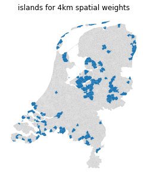

```python
ax = df.plot(color='lightgrey', figsize=(5,5))
df.iloc[wd4.islands].plot(ax=ax)
ax.set_title('islands for 4km spatial weights')
ax.axis('off')
plt.show()
```

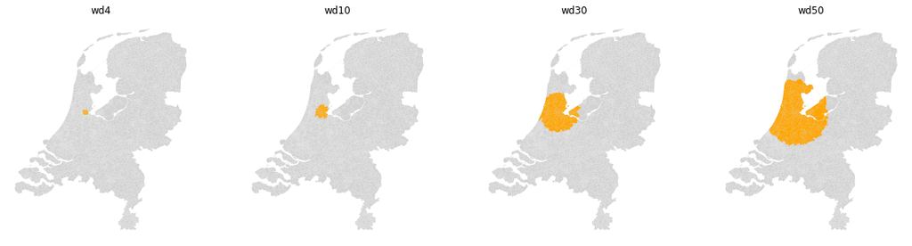

```python
fix, ax = plt.subplots(1,4,figsize=(5*4,5))
for i in range(4):
    df.plot(ax=ax[i], color='lightgrey')
    df.iloc[list(wds[i][0].keys())].plot(ax=ax[i], color='orange')
    ax[i].set_title(wdsN[i])
    ax[i].axis('off')
plt.show()
```

## Spatial lag

Using the spatial weights we just created, we calculate the following for each postcode:

- average log(kg) received within 4, 10, 30km radius (spatial lag)
- total log(kg) received within 4, 10, 30km radius
- average log(kg) processed within 4, 10, 30km radius (spatial lag)
- total log(kg) processed within 4, 10, 30km radius
- average log(kg) created within 4, 10, 30km radius (spatial lag)
- total log(kg) created within 4, 10, 30km radius

### Average secondary resources received within 4, 10, 30km radius

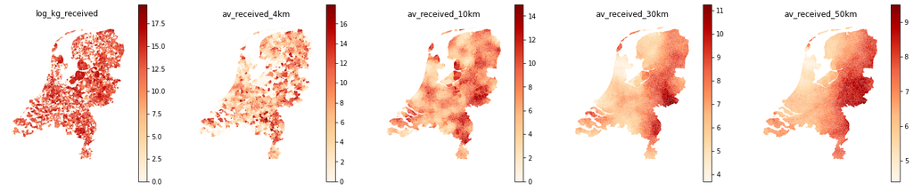

```python
# spatial lag for log values
tName = ['av_received_4km', 'av_received_10km', 'av_received_30km', 'av_received_50km']
wds = [wd4, wd10, wd30, wd50] # spatial weights of 3, 10, 30km radius

# calculate spatial lag
for i in range(4):
    y = df['log_kg_received']
    ylag = lp.weights.lag_spatial(wds[i], y)
    df[tName[i]] = ylag

# plot log(kg)
fig, ax = plt.subplots(1,5,figsize=(5*5,5))
df.plot(ax=ax[0], column='log_kg_received', cmap='OrRd', legend=True)
ax[0].set_title('log_kg_received')
ax[0].axis('off')

# plot spatial lag for log(kg)
for i in range(4):
    df.plot(ax=ax[i+1], column=tName[i], cmap='OrRd', legend=True)
    ax[i+1].set_title(tName[i])
    ax[i+1].axis('off')

# display
plt.show()
```

### Total secondary resources received within 4, 10, 30km radius

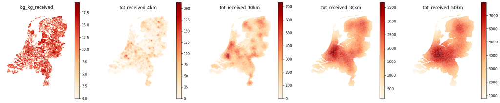

```python
# total kg received at 4, 10, 30km
tName = ['tot_received_4km', 'tot_received_10km', 'tot_received_30km', 'tot_received_50km']
wds = [wd4, wd10, wd30, wd50] # spatial weights of 3, 10, 30km radius

# calculate total kg received using the 4 spatial weights (wds)
for i in range(4):
    t = tName[i] # not sure why this needs to be done, but without it, returns error 'index out of range'.
    wd = wds[i]
    totalReceived = []
    for i in range(len(df)):
        total = df.iloc[list(wd[i].keys())].log_kg_received.sum()
        totalReceived.append(total)
    df[t] = pd.Series(totalReceived)

# plot log_kg
fig, ax = plt.subplots(1,5,figsize=(5*5,5))
df.plot(ax=ax[0], column='log_kg_received', cmap='OrRd', legend=True)
ax[0].set_title('log_kg_received')
ax[0].axis('off')

# plot total received for 4, 10, 30, 50km
for i in range(4):
    df.plot(ax=ax[i+1], column=tName[i], cmap='OrRd', legend=True)
    ax[i+1].set_title(tName[i])
    ax[i+1].axis('off')

# display
plt.show()
```

### Average waste processed within 4, 10, 30km radius

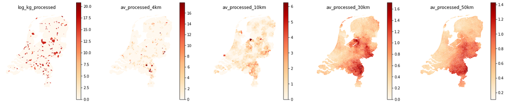

```python
ev = 'log_kg_processed' # explanatory variable
tName = ['av_processed_4km', 'av_processed_10km', 'av_processed_30km', 'av_processed_50km']
wds = [wd4, wd10, wd30, wd50] # spatial weights of 3, 10, 30km radius

# calculate spatial lag
for i in range(4):
    y = df['log_kg_processed']
    ylag = lp.weights.lag_spatial(wds[i], y)
    df[tName[i]] = ylag

# plot log(kg)
fig, ax = plt.subplots(1,5,figsize=(5*5,5))
df.plot(ax=ax[0], column='log_kg_processed', cmap='OrRd', legend=True)
ax[0].set_title('log_kg_processed')
ax[0].axis('off')

# plot spatial lag for log(kg)
for i in range(4):
    df.plot(ax=ax[i+1], column=tName[i], cmap='OrRd', legend=True)
    ax[i+1].set_title(tName[i])
    ax[i+1].axis('off')

# display
plt.show()
```

### Total waste processed within 4, 10, 30km radius

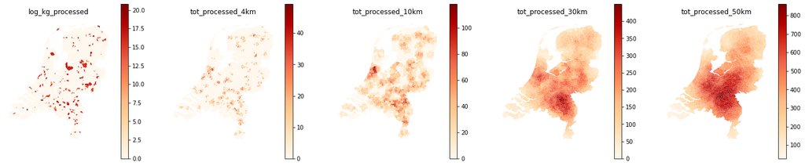

```python
ev = 'log_kg_processed' # explanatory variable
tName = ['tot_processed_4km', 'tot_processed_10km', 'tot_processed_30km', 'tot_processed_50km']
wds = [wd4, wd10, wd30, wd50] # spatial weights of 3, 10, 30km radius

# calculate total kg processed using the 4 spatial weights (wds)
for i in range(4):
    t = tName[i] # not sure why this needs to be done, but without it, returns error 'index out of range'.
    wd = wds[i]
    totalReceived = []
    for i in range(len(df)):
        total = df.iloc[list(wd[i].keys())].log_kg_processed.sum()
        totalReceived.append(total)
    df[t] = pd.Series(totalReceived)

# plot log_kg
fig, ax = plt.subplots(1,5,figsize=(5*5,5))
df.plot(ax=ax[0], column=ev, cmap='OrRd', legend=True)
ax[0].set_title(ev)
ax[0].axis('off')

# plot total received for 4, 10, 30, 50km
for i in range(4):
    df.plot(ax=ax[i+1], column=tName[i], cmap='OrRd', legend=True)
    ax[i+1].set_title(tName[i])
    ax[i+1].axis('off')

# display
plt.show()
```

### Making df for waste produced

Using ontvangst 2019 dataset. Herkomst is the origin of waste (most accurate), ontdoener is the collector or origin of waste (less accurate)

```python
# read df
wp = feather.read_dataframe('../data/lma/ontv_2019.feather')
wp = wp[['Ontdoener Postcode', 'Locatie van Herkomst Postcode', 'Locatie van Herkomst Land', 'Verwerker Postcode', 'Totaal Gewicht (KG) Totaal']]
wp.rename(columns={'Ontdoener Postcode': 'ontPc', 'Locatie van Herkomst Postcode': 'herPc', 'Locatie van Herkomst Land': 'land',
                   'Verwerker Postcode': 'verPc', 'Totaal Gewicht (KG) Totaal': 'kg_produced'}, inplace=True)
wp.land = wp.land.str.lower()

# pick postcode (prefer herkomst)
def pcPicker(row):
    if row.herPc == None:
        return row.ontPc
    else:
        return row.herPc
wp['pc'] = wp.apply(lambda row: pcPicker(row), axis=1)

# drop empty postcodes, irrelevant rows, rows from other countries
wp = wp[~wp.pc.isna()]
wp = wp[['pc', 'land', 'kg_produced']]
wp.land = wp.land.fillna('') # dropped some NL flows here, will need to use regex to find postcodes of NL
wp = wp[wp.land == 'nederland'] # only pick nl flows
wp['lenPc'] = wp.pc.map(lambda x: len(x)) # drop wrongly inputted pcs
wp = wp[wp.lenPc <= 6]
wp.pc = wp.pc.str[:4]
wp = wp[wp.pc != 'M278']
wp.pc = wp.pc.astype('int64')

# group by pc
wp = wp[['pc', 'kg_produced']]
wp = wp.groupby('pc').sum().reset_index()

# add pc geometry
wp = pd.merge(nl_pc4, wp, how='left', left_on='PC4', right_on='pc')
wp = wp[['PC4', 'geometry', 'kg_produced']]

# display
print(wp.shape)
wp.head()
```

```
(4068, 3)
```

|  | PC4 | geometry | kg_produced |
| --- | --- | --- | --- |
| 0 | 1011 | POLYGON ((122183.249 487939.201, 122183.241 48... | 6571967.0 |
| 1 | 1012 | POLYGON ((122049.209 488210.972, 122120.438 48... | 12248504.0 |
| 2 | 1013 | POLYGON ((120047.752 491287.512, 120402.310 49... | 127265363.0 |
| 3 | 1014 | MULTIPOLYGON (((120388.477 489860.258, 120387.... | 17358717.0 |
| 4 | 1015 | POLYGON ((120603.279 488589.178, 120640.375 48... | 3797070.0 |

```python
# only run this once!
df = pd.merge(df, wp, how='left', left_on='pc', right_on='PC4')
df = df.drop(labels=['PC4', 'geometry_y'], axis=1)
df = df.rename(columns={'geometry_x': 'geometry'})
```

```python
def log(x):
    if x > 0:
        return np.log(x)
    else:
        return 0
df['log_kg_produced'] = df.kg_produced.map(lambda x: log(x))
df = df[['pc', 'geometry', 'centroid', 'kg_received', 'kg_processed',
       'kg_produced', 'log_kg_received', 'log_kg_processed', 'log_kg_produced', 'av_received_4km',
       'av_received_10km', 'av_received_30km', 'av_received_50km',
       'tot_received_4km', 'tot_received_10km', 'tot_received_30km',
       'tot_received_50km', 'av_processed_4km', 'av_processed_10km',
       'av_processed_30km', 'av_processed_50km', 'tot_processed_4km',
       'tot_processed_10km', 'tot_processed_30km', 'tot_processed_50km']]
```

### Average waste produced within 4, 10, 30km radius

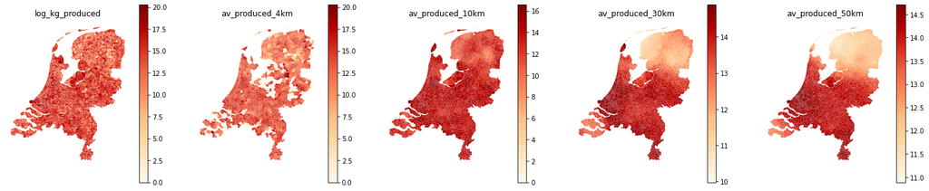

```python
ev = 'log_kg_produced' # explanatory variable
tName = ['av_produced_4km', 'av_produced_10km', 'av_produced_30km', 'av_produced_50km']
wds = [wd4, wd10, wd30, wd50] # spatial weights of 3, 10, 30km radius

# calculate spatial lag
for i in range(4):
    y = df['log_kg_produced']
    ylag = lp.weights.lag_spatial(wds[i], y)
    df[tName[i]] = ylag

# plot log(kg)
fig, ax = plt.subplots(1,5,figsize=(5*5,5))
df.plot(ax=ax[0], column='log_kg_produced', cmap='OrRd', legend=True)
ax[0].set_title('log_kg_produced')
ax[0].axis('off')

# plot spatial lag for log(kg)
for i in range(4):
    df.plot(ax=ax[i+1], column=tName[i], cmap='OrRd', legend=True)
    ax[i+1].set_title(tName[i])
    ax[i+1].axis('off')

# display
plt.show()
```

### Total waste produced within 4, 10, 30km radius

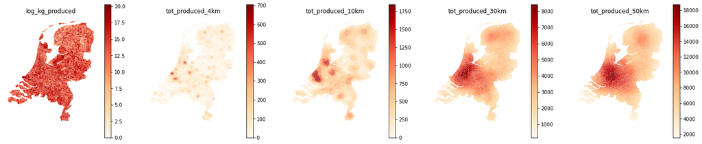

```python
ev = 'log_kg_produced' # explanatory variable
tName = ['tot_produced_4km', 'tot_produced_10km', 'tot_produced_30km', 'tot_produced_50km']
wds = [wd4, wd10, wd30, wd50] # spatial weights of 3, 10, 30km radius

# calculate total kg processed using the 4 spatial weights (wds)
for i in range(4):
    t = tName[i] # not sure why this needs to be done, but without it, returns error 'index out of range'.
    wd = wds[i]
    totalReceived = []
    for i in range(len(df)):
        total = df.iloc[list(wd[i].keys())].log_kg_produced.sum()
        totalReceived.append(total)
    df[t] = pd.Series(totalReceived)

# plot log_kg
fig, ax = plt.subplots(1,5,figsize=(5*5,5))
df.plot(ax=ax[0], column=ev, cmap='OrRd', legend=True)
ax[0].set_title(ev)
ax[0].axis('off')

# plot total received for 4, 10, 30, 50km
for i in range(4):
    df.plot(ax=ax[i+1], column=tName[i], cmap='OrRd', legend=True)
    ax[i+1].set_title(tName[i])
    ax[i+1].axis('off')

# display
plt.show()
```

## Exploring correlations

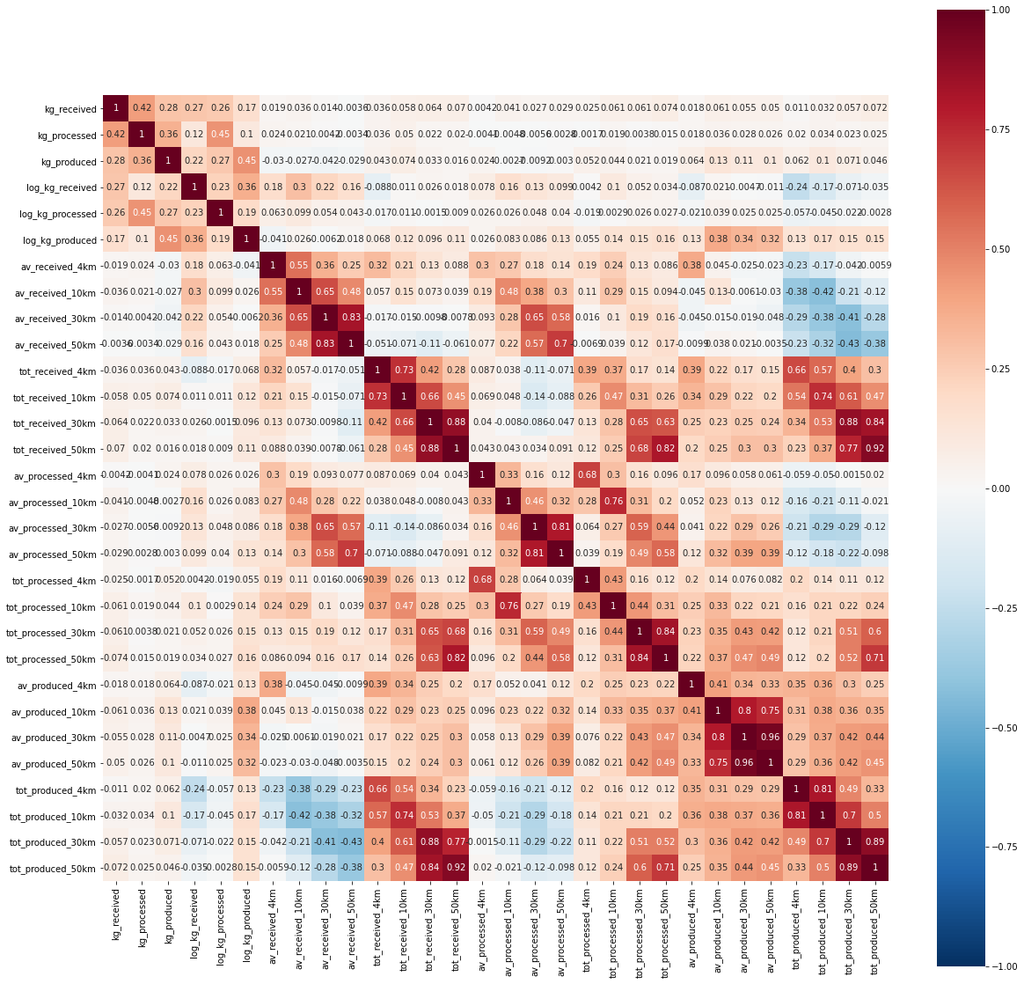

```python
dfCorr = df.drop(labels=['pc', 'centroid', 'geometry'], axis=1)
norm = plt.Normalize(-1,1)
fig, ax = plt.subplots(figsize=(20,20))
sn.heatmap(dfCorr.corr(), square=True, annot=True, ax=ax, cmap='RdBu_r', norm=norm)
plt.show()
```

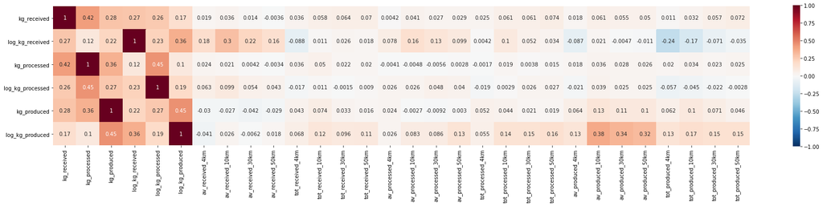

```python
dfCorr = df.drop(labels=['pc', 'centroid', 'geometry'], axis=1)
dfCorr = dfCorr.corr().loc[['kg_received', 'log_kg_received', 'kg_processed', 'log_kg_processed', 'kg_produced', 'log_kg_produced']]
norm = plt.Normalize(-1,1)
fig, ax = plt.subplots(figsize=(30,5))
sn.heatmap(dfCorr, square=True, annot=True, ax=ax, norm=norm, cmap='RdBu_r')
plt.show()
```

[figure not shown]

```python
sn.pairplot(dfCorr)
plt.show()
```